# INN Hotels Project

### Observations on number of weekend nights

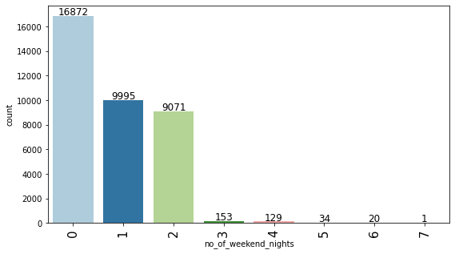

```python
labeled_barplot(data, "no_of_weekend_nights")
```

```python
data.groupby("no_of_weekend_nights")["booking_status"].count()
```

```
no_of_weekend_nights
0    16872
1     9995
2     9071
3      153
4      129
5       34
6       20
7        1
Name: booking_status, dtype: int64
```

### Observations on required car parking space

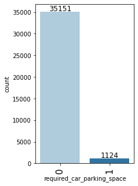

```python
labeled_barplot(data, "required_car_parking_space")
```

### Observations on type of meal plan

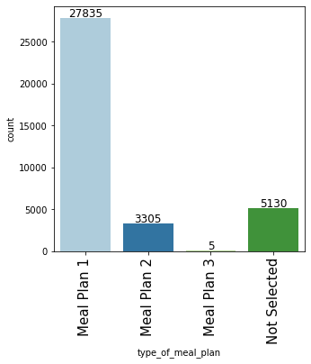

```python
labeled_barplot(data, "type_of_meal_plan")
```

- Plot shows that meal plan 1 which has only Break fast is more demanding.

### Observations on room type reserved

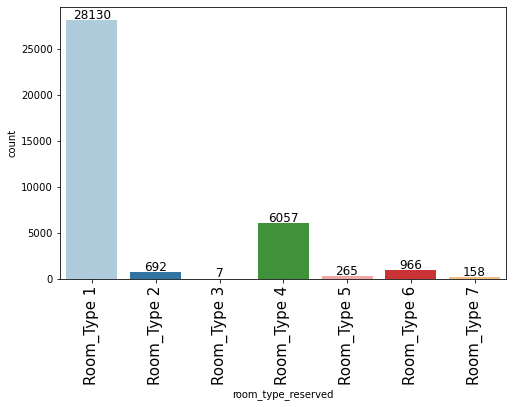

```python
labeled_barplot(data, "room_type_reserved")
```

### Observations on arrival month

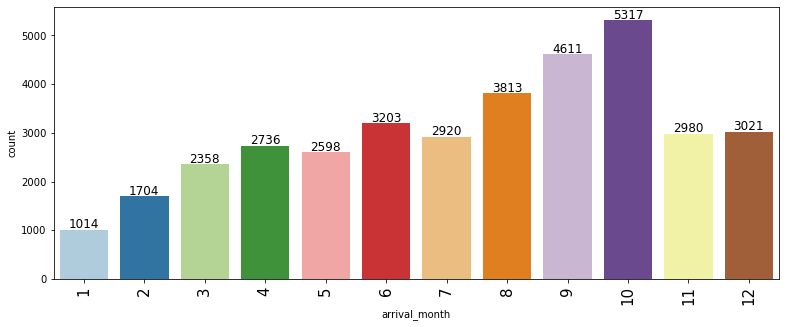

```python
labeled_barplot(data, "arrival_month")
```

- Plot shows that arrival_month 10 has more bookings compared to other months but on the average the other months are good.

### Observations on market segment type

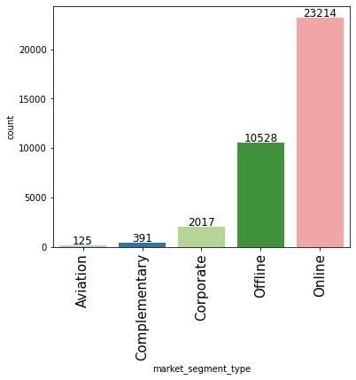

```python
labeled_barplot(data, "market_segment_type")
```

- Plot shows that online bookings are more compared to other segment types.

### Observations on number of special requests

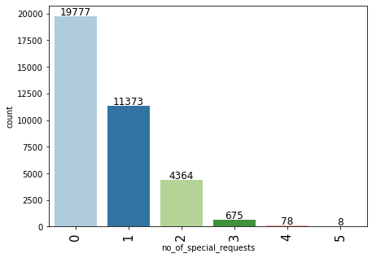

```python
labeled_barplot(data, "no_of_special_requests")
```

### Observations on booking status

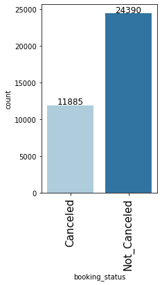

```python
labeled_barplot(data, "booking_status")
```

- There are many bookings which were not_cancelled compared to cancelled but we are interested in cancelled status why that many bookings were cancelled.

**Let's encode Canceled bookings to 1 and Not_Canceled as 0 for further analysis**

```python
data["booking_status"] = data["booking_status"].apply(
    lambda x: 1 if x == "Canceled" else 0
)
```

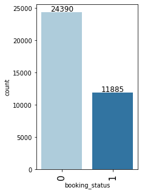

```python
labeled_barplot(data, "booking_status")
```

### Bivariate Analysis

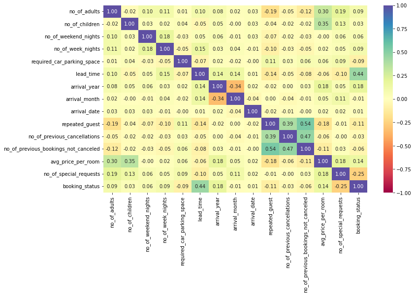

```python
cols_list = data.select_dtypes(include=np.number).columns.tolist()

plt.figure(figsize=(12, 7))
sns.heatmap(
    data[cols_list].corr(), annot=True, vmin=-1, vmax=1, fmt=".2f", cmap="Spectral"
)
plt.show()
```

**Creating functions that will help us with further analysis.**

```python
### function to plot distributions wrt target


def distribution_plot_wrt_target(data, predictor, target):

    fig, axs = plt.subplots(2, 2, figsize=(12, 10))

    target_uniq = data[target].unique()

    axs[0, 0].set_title("Distribution of target for target=" + str(target_uniq[0]))
    sns.histplot(
        data=data[data[target] == target_uniq[0]],
        x=predictor,
        kde=True,
        ax=axs[0, 0],
        color="teal",
        stat="density",
    )

    axs[0, 1].set_title("Distribution of target for target=" + str(target_uniq[1]))
    sns.histplot(
        data=data[data[target] == target_uniq[1]],
        x=predictor,
        kde=True,
        ax=axs[0, 1],
        color="orange",
        stat="density",
    )

    axs[1, 0].set_title("Boxplot w.r.t target")
    sns.boxplot(data=data, x=target, y=predictor, ax=axs[1, 0], palette="gist_rainbow")

    axs[1, 1].set_title("Boxplot (without outliers) w.r.t target")
    sns.boxplot(
        data=data,
        x=target,
        y=predictor,
        ax=axs[1, 1],
        showfliers=False,
        palette="gist_rainbow",
    )

    plt.tight_layout()
    plt.show()
```

```python
def stacked_barplot(data, predictor, target):
    """
    Print the category counts and plot a stacked bar chart

    data: dataframe
    predictor: independent variable
    target: target variable
    """
    count = data[predictor].nunique()
    sorter = data[target].value_counts().index[-1]
    tab1 = pd.crosstab(data[predictor], data[target], margins=True).sort_values(
        by=sorter, ascending=False
    )
    print(tab1)
    print("-" * 120)
    tab = pd.crosstab(data[predictor], data[target], normalize="index").sort_values(
        by=sorter, ascending=False
    )
    tab.plot(kind="bar", stacked=True, figsize=(count + 5, 5))
    plt.legend(
        loc="lower left", frameon=False,
    )
    plt.legend(loc="upper left", bbox_to_anchor=(1, 1))
    plt.show()
```

**Hotel rates are dynamic and change according to demand and customer demographics. Let's see how prices vary across different market segments**

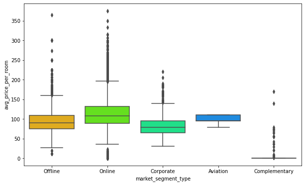

```python
plt.figure(figsize=(10, 6))
sns.boxplot(
    data=data, x="market_segment_type", y="avg_price_per_room", palette="gist_rainbow"
)
plt.show()
```

- online market_segment_type has many outliers for the avg_price_per_room and offline segment type also has outliers

**Let's see how booking status varies across different market segments. Also, how average price per room impacts booking status**

```
booking_status           0      1    All
market_segment_type
All                  24390  11885  36275
Online               14739   8475  23214
Offline               7375   3153  10528
Corporate             1797    220   2017
Aviation                88     37    125
Complementary          391      0    391
------------------------------------------------------------------------------------------------------------------------
```

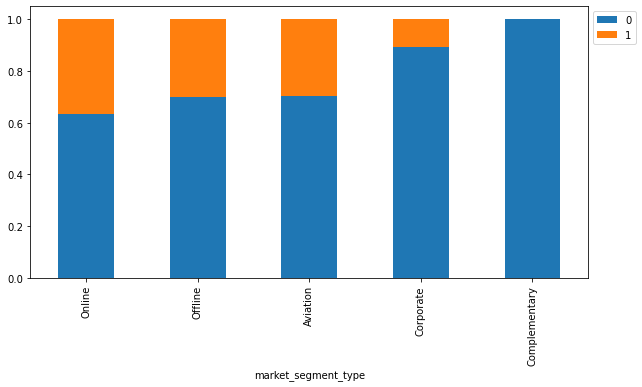

```python
stacked_barplot(data, "market_segment_type", "booking_status")
```

- online, offline,aviation market_segment_type has more cancellations compared to the corporate

**Many guests have special requirements when booking a hotel room. Let's see how it impacts cancellations**

```
booking_status              0      1    All
no_of_special_requests
All                     24390  11885  36275
0                       11232   8545  19777
1                        8670   2703  11373
2                        3727    637   4364
3                         675      0    675
4                          78      0     78
5                           8      0      8
------------------------------------------------------------------------------------------------------------------------
```

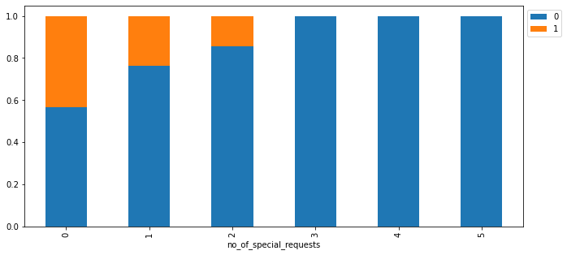

```python
stacked_barplot(data, "no_of_special_requests", "booking_status")
```

**Let's see if the special requests made by the customers impacts the prices of a room**

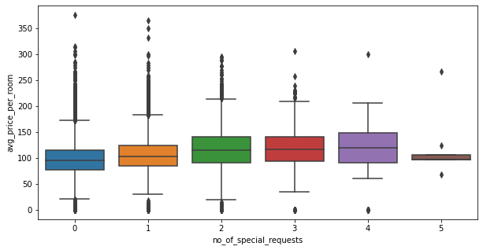

```python
plt.figure(figsize=(10, 5))
sns.boxplot(data=data, x="no_of_special_requests", y="avg_price_per_room")
plt.show()
```

## Data Preprocessing

- Missing value treatment (if needed)
- Feature engineering (if needed)
- Outlier detection and treatment (if needed)
- Preparing data for modeling
- Any other preprocessing steps (if needed)

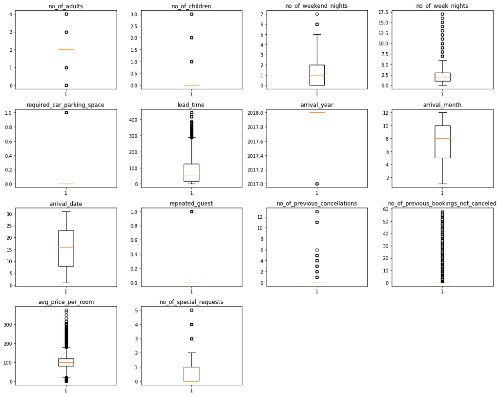

```python
# outlier detection using boxplot
numeric_columns = data.select_dtypes(include=np.number).columns.tolist()
# dropping booking_status
numeric_columns.remove("booking_status")

plt.figure(figsize=(15, 12))

for i, variable in enumerate(numeric_columns):
    plt.subplot(4, 4, i + 1)
    plt.boxplot(data[variable], whis=1.5)
    plt.tight_layout()
    plt.title(variable)

plt.show()
```

**We saw earlier that there is a positive correlation between booking status and average price per room. Let's analyze it**

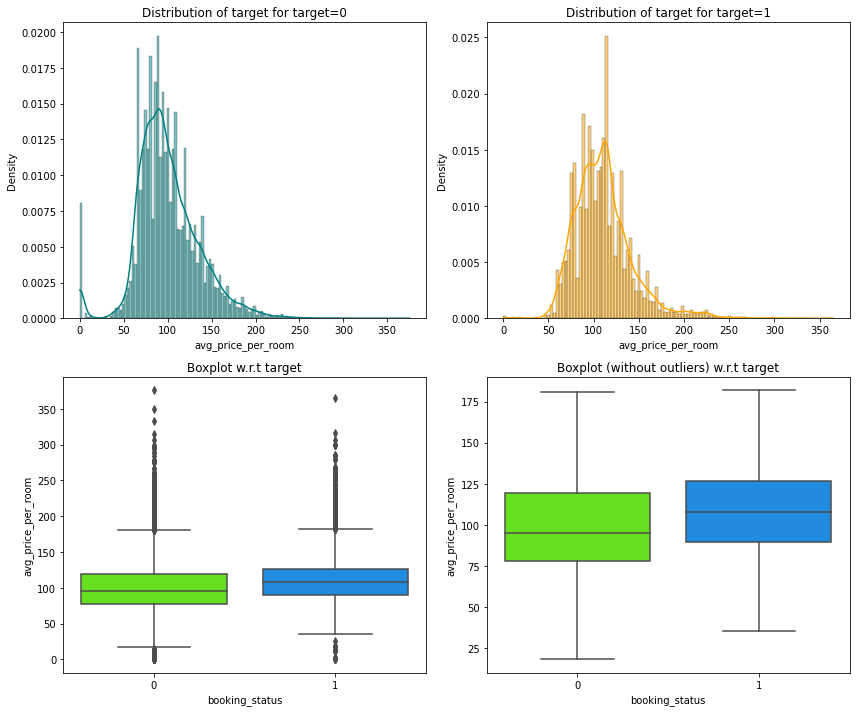

```python
distribution_plot_wrt_target(data, "avg_price_per_room", "booking_status")
```

**There is a positive correlation between booking status and lead time also. Let's analyze it further**

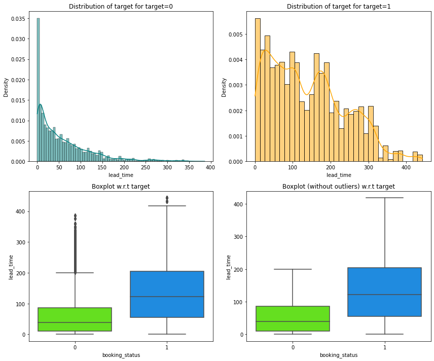

```python
distribution_plot_wrt_target(data, "lead_time", "booking_status")
```

**Generally people travel with their spouse and children for vacations or other activities. Let's create a new dataframe of the customers who traveled with their families and analyze the impact on booking status.**

```python
family_data = data[(data["no_of_children"] >= 0) & (data["no_of_adults"] > 1)]
family_data.shape
```

```
(28441, 18)
```

```python
family_data["no_of_family_members"] = (
    family_data["no_of_adults"] + family_data["no_of_children"]
)
```

```
booking_status            0     1    All
no_of_family_members
All                   18456  9985  28441
2                     15506  8213  23719
3                      2425  1368   3793
4                       514   398    912
5                        11     6     17
------------------------------------------------------------------------------------------------------------------------
```

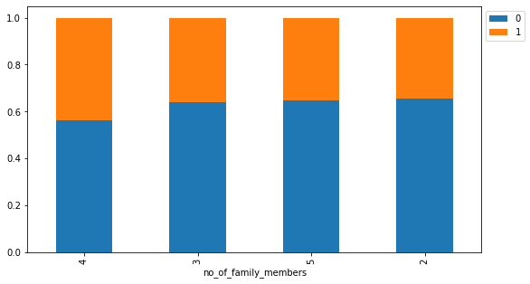

```python
stacked_barplot(
    family_data, "no_of_family_members", "booking_status"
)  ## Complete the code to plot stacked barplot for no of family members and booking status
```

**Let's do a similar analysis for the customer who stay for at least a day at the hotel.**

```python
stay_data = data[(data["no_of_week_nights"] > 0) & (data["no_of_weekend_nights"] > 0)]
stay_data.shape
```

```
(17094, 18)
```